# Airline passenger Satisfaction

Name: Group 173 Mohammed Usman E Ghani (S3901999)

### Phase 2: Statistical Modelling

- Introduction
  - Phase 1 summary
  - Report overview
  - Overview of methodolgy
- Statistical Modeling
  - Model Overview (Full model)
  - One-hot encoding
  - Model fitting
  - Diagnostic checks (Full model)
  - Backward feature selection
  - Backward feature selection (adjusted p-value)
- Critique & Limitations
- Summary & Conclusions
  - Project Summary
  - Summary of Findings
  - Conclusion
- Reference

### Introduction

#### Phase 1 summary

In phase 1 report, the overall customer satisfactory level of an airline passenger was analysed based on various explanatory/descriptive variables i.e. passenger satisfaction levels for various services offered by the USA airline. The report was focused on exploring the relationships between different types of customers and their response to certain aspects of their flight experience, and how these experiences affected their overall flying experience.

After thoroughly studying the dataset, we started by performing data cleaning procedures to the the Airline passenger satisfaction dataset. We dropped any redundant columns and renamed most of the column names for better readability. The next step was to check for any missing values and outliers in the dataset to make sure that extreme values do not contaminate the overall dataset. Finally, the data type of each features were also took into consideration and changed some of it (like changing float to int which was caused by null responses in some of the columns) for better consistency and usability of dataset. After applying all the required data cleaning and pre-processing techniques to make sure that the data is appropriate to be used in phase 2, we randomly sampled 5000 rows (since there were 119204 rows in total) and generated various visualisations from them.

A range of data visualisations techniques were utilised to get a better insight into the relationships within the dataset, from univariate plots representing the overall satisfaction ratings (target feature) to multi-variate plots displaying various factors influencing the customer feedback.

It was concluded that the overall satisfaction feedback for the airline services was mostly neutral or negative. Moreover, the flying class had a significant impact on the satisfaction levels, customers opted to fly lower class returned an overall negative response compared to upper business class. All of this was supported using a range of data visualisations techniques to further visualise any correlations.

### Report Overview

In this second phase of the project, we aim to apply statistical modeling techniques to the pre- processed Airline satisfaction dataset obtained from phase 1 report. This will help us approach data analysis in a strategic way and make better real world predictions. In order to make the problem a regression one, a continuous numerical feature, arrival delay in minutes will be selected instead of binary categorical variable. This is to also ensure that the features used is statistically powerful, has simpler interpretation and is suitable for modeling.

The aim of this project is to put into application predictive modeling techniques to explore the relationship between explanatory variables and response variable. A statistical model will be produced after applying various modeling techniques like backward feature selection for making any patterns present observable. As with many aspects of data modeling, there will be some limitations on its usability which will be discussed later in the report.

### Overview of methodology

We first gather the cleaned data from the phase 1 report. After this, one- hot encoding will be implemented depending upon the type of variables. We begin by selecting most appropriate predictor and a response variables. With the help of a regression formula, all the independent variables are transformed to a string which will later help us in ordinary least square method. The multiple linear regression to be modeled attempts to demonstrate the relation amongst dependent and independent variables using statistical techniques. We begin by selecting most appropriate predictor and a response variables. Model fitting will be utilised to predicts the arrival delay of airlines in minutes. In order to convert categorical features to multiple binary features, one - hot encoding will be implemented.To get a better view of the fitted values, a new data frame is created containing the arrival delay column from the original data frame, regression residuals and the fitted values (predicted values) obtained from OLS. To further visualise the 3 column data frame, graphs are plotted comparing each variable which will help perform diagnostic checks on the model.

After this, a fitting model method - backward feature selection is implemented to make sure that the least statistically significant variables are eliminated i.e. variables with high p-values. Elimination of these insignificant variables reduces the risks of unnecessary complications to the model. Further diagnostic checks are conducted on this reduced model obtained from backward feature selection which will contribute to improving the efficiency of the a model.

## Statistical Modeling

### Model Overview

We are using linear multiple linear regression as our principle statistical technique. The multiple linear regression model attempts to demonstrate the relation amongst dependent and independent variables using statistical techniques. Model fitting technique will be utilised to predicts the arrival delay of airlines in minutes. With the help of a regression formula, all the independent variables are transformed to a string which will later help us in ordinary least square (OLS) modeling. one - hot encoding will be implemented which will make the variables more expressive and to ensure that the machine learning algorithm works efficiently. This is then used to get to modeling of one- hot encoded data usinf OLS. Although doing this provides us with a extensive details and figures, p-values and R-squared values will be helpful the most. Then, backward feature selection is helpful to make sure that the least statistically significant variables are eliminated i.e. variables with high p-values. Elimination of these insignificant variables reduces the risks of unnecessary complications to the model

Importing all the required modules.

```python
# Module initiallisation
import numpy as np
import pandas as pd
import io
import requests
import matplotlib.pyplot as plt
import seaborn as sns
from IPython.display import display, HTML
import statsmodels.api as sm
import statsmodels.formula.api as smf
import patsy

import warnings
warnings.filterwarnings('ignore')
%config InlineBackend.figure_format = 'retina'
%matplotlib inline
plt.style.use("ggplot")
pd.set_option('display.max_columns', None)
```

### Model fitting

We start by importing and declaring the pre- processed dataset from phase 1. The index column will also be dropped

```python
#satis_df is a cleaned pre- processed csv file obtained from phase 1 report
satis_df = pd.read_csv('phase2_Group173.csv')

satis_df = satis_df.reset_index(drop=True)
```

Retrieving a random sample from the data frame to ensure this has been completed successfully. This will be the full model, consisting all the variables of interest.

```python
# sample data
satis_df.head()
```

|  | gender | customer_type | age | travel_type | customer_class | flight_distance | wifi_service | depart_arrive_time | online_booking | gate_location | food_drink | online_boarding | seat_comfort | entertainment | onboard_service | legroom_service | baggage_handle | checkin_service | cleanliness | departure_delay | arrival_delay | overall_satisfaction |
| --- | --- | --- | --- | --- | --- | --- | --- | --- | --- | --- | --- | --- | --- | --- | --- | --- | --- | --- | --- | --- | --- | --- |
| 0 | Male | Loyal Customer | 21 | Personal Travel | Eco | 760 | 1 | 3 | 1 | 3 | 2 | 1 | 2 | 2 | 3 | 2 | 3 | 2 | 2 | 0 | 0 | neutral or dissatisfied |
| 1 | Female | Loyal Customer | 38 | Business travel | Business | 651 | 2 | 1 | 1 | 1 | 1 | 4 | 3 | 2 | 2 | 2 | 2 | 1 | 2 | 0 | 0 | neutral or dissatisfied |
| 2 | Male | Loyal Customer | 37 | Business travel | Business | 1199 | 3 | 3 | 2 | 3 | 2 | 4 | 5 | 3 | 3 | 2 | 3 | 4 | 1 | 0 | 14 | satisfied |
| 3 | Female | disloyal Customer | 17 | Business travel | Eco | 964 | 1 | 1 | 1 | 5 | 3 | 1 | 5 | 3 | 1 | 1 | 4 | 4 | 3 | 0 | 5 | neutral or dissatisfied |
| 4 | Female | Loyal Customer | 38 | Business travel | Business | 2938 | 3 | 3 | 3 | 3 | 4 | 4 | 5 | 5 | 5 | 5 | 5 | 4 | 3 | 0 | 1 | satisfied |

To get started, we create a formula for regression which will help us with Ordinary least square method in the next steps. This involves dropping our target feature and installing the rest of the variables into a string, instead of having to add all the independent features one by one. However, one limitation to this is that automated feature selection will not be possible unless a new program is constructed to support this.

```python
regression_formula_descriptive = ' + '.join(satis_df.drop(columns='arrival_delay').columns)
regression_formula = 'arrival_delay ~ ' + regression_formula_descriptive
print('Regression formula: ', regression_formula)
```

```
Regression formula:  arrival_delay ~ gender + customer_type + age + travel_type + customer_class + flight_distance + wifi_service + depart_arrive_time + online_booking + gate_location + food_drink + online_boarding + seat_comfort + entertainment + onboard_service + legroom_service + baggage_handle +…
```

Since our data frame contains categorical features, they would have to be converted to multiple binary features for successful model fitting using statsmodels python package. As the number of different categorical features in the columns is less, one-hot encoding can be effectively used. In order to this, one -hot encoding is a clear choice as these columns carry no hierarchical order. With the help of pandas, get_dummies() function can be used to easily to transform categorical features to one-hot-encoding.

```python
# one-hot-encoding for all categorical features
# for this to work correctly, variable data types must be numeric or categorical
encoded_df = pd.get_dummies(satis_df, drop_first=True)
encoded_df.head()
```

|  | age | flight_distance | wifi_service | depart_arrive_time | online_booking | gate_location | food_drink | online_boarding | seat_comfort | entertainment | onboard_service | legroom_service | baggage_handle | checkin_service | cleanliness | departure_delay | arrival_delay | gender_Male | customer_type_disloyal Customer | travel_type_Personal Travel | customer_class_Eco | customer_class_Eco Plus | overall_satisfaction_satisfied |
| --- | --- | --- | --- | --- | --- | --- | --- | --- | --- | --- | --- | --- | --- | --- | --- | --- | --- | --- | --- | --- | --- | --- | --- |
| 0 | 21 | 760 | 1 | 3 | 1 | 3 | 2 | 1 | 2 | 2 | 3 | 2 | 3 | 2 | 2 | 0 | 0 | 1 | 0 | 1 | 1 | 0 | 0 |
| 1 | 38 | 651 | 2 | 1 | 1 | 1 | 1 | 4 | 3 | 2 | 2 | 2 | 2 | 1 | 2 | 0 | 0 | 0 | 0 | 0 | 0 | 0 | 0 |
| 2 | 37 | 1199 | 3 | 3 | 2 | 3 | 2 | 4 | 5 | 3 | 3 | 2 | 3 | 4 | 1 | 0 | 14 | 1 | 0 | 0 | 0 | 0 | 1 |
| 3 | 17 | 964 | 1 | 1 | 1 | 5 | 3 | 1 | 5 | 3 | 1 | 1 | 4 | 4 | 3 | 0 | 5 | 0 | 1 | 0 | 1 | 0 | 0 |
| 4 | 38 | 2938 | 3 | 3 | 3 | 3 | 4 | 4 | 5 | 5 | 5 | 5 | 5 | 4 | 3 | 0 | 1 | 0 | 0 | 0 | 0 | 0 | 1 |

One-hot encoding using pandas causes creation of additional columns with one hot encoded data for every distinct value. The new column names are not not ready yet to be used in ordinary least squares regression step as they contain white spaces. Moreover, the column names are inconsistent. To overcome this, the column names are re-named to remove any spaces and for better readability.

```python
# one hot encoding caused a change in name for some columns. so we rename customer_class_Eco plus to customer_class_Eco_plus
#And also rename customer_type_disloyal Customer, travel_type_Personal Travel, customer_class_Eco and overall_satisfaction_satisfied


encoded_df = encoded_df.rename(columns={'customer_class_Eco Plus': 'Economic_Plus', 'customer_class_Eco': 'Economic','customer_type_disloyal Customer': 'disloyal_customer', 'travel_type_Personal Travel': 'Personal_travel', 'overall_satisfaction_satisfied': 'overall_satisfied'})
encoded_df.head()
```

|  | age | flight_distance | wifi_service | depart_arrive_time | online_booking | gate_location | food_drink | online_boarding | seat_comfort | entertainment | onboard_service | legroom_service | baggage_handle | checkin_service | cleanliness | departure_delay | arrival_delay | gender_Male | disloyal_customer | Personal_travel | Economic | Economic_Plus | overall_satisfied |
| --- | --- | --- | --- | --- | --- | --- | --- | --- | --- | --- | --- | --- | --- | --- | --- | --- | --- | --- | --- | --- | --- | --- | --- |
| 0 | 21 | 760 | 1 | 3 | 1 | 3 | 2 | 1 | 2 | 2 | 3 | 2 | 3 | 2 | 2 | 0 | 0 | 1 | 0 | 1 | 1 | 0 | 0 |
| 1 | 38 | 651 | 2 | 1 | 1 | 1 | 1 | 4 | 3 | 2 | 2 | 2 | 2 | 1 | 2 | 0 | 0 | 0 | 0 | 0 | 0 | 0 | 0 |
| 2 | 37 | 1199 | 3 | 3 | 2 | 3 | 2 | 4 | 5 | 3 | 3 | 2 | 3 | 4 | 1 | 0 | 14 | 1 | 0 | 0 | 0 | 0 | 1 |
| 3 | 17 | 964 | 1 | 1 | 1 | 5 | 3 | 1 | 5 | 3 | 1 | 1 | 4 | 4 | 3 | 0 | 5 | 0 | 1 | 0 | 1 | 0 | 0 |
| 4 | 38 | 2938 | 3 | 3 | 3 | 3 | 4 | 4 | 5 | 5 | 5 | 5 | 5 | 4 | 3 | 0 | 1 | 0 | 0 | 0 | 0 | 0 | 1 |

Creation of new columns from one- hot encoding warrant the need to revisit the regression formula. Newly created independent variables are installed into the string.

```python
regression_formula_descriptive = ' + '.join(encoded_df.drop(columns='arrival_delay').columns)
regression_formula = 'arrival_delay ~ ' + regression_formula_descriptive
print('regression_formula: ', regression_formula)
```

```
regression_formula:  arrival_delay ~ age + flight_distance + wifi_service + depart_arrive_time + online_booking + gate_location + food_drink + online_boarding + seat_comfort + entertainment + onboard_service + legroom_service + baggage_handle + checkin_service + cleanliness + departure_delay + gende…
```

#### Ordinary least squares

Ordinary least squares regression creates a model by estimating unknown parameters which will reduce the total squared errors between the predictor variable and the response variable. We can now proceed to modeling the prepared data with OLS regression.

This is done using statsmodels module to implement OLS method of regression which takes in 'regression_formula' as the formula parameter and 'encoded_df' as the dataframe, both constructed in previous steps.

```python
model_full = sm.formula.ols(formula=regression_formula, data=encoded_df)

model_full_fitted = model_full.fit()

print(model_full_fitted.summary())
```

```
                            OLS Regression Results
==============================================================================
Dep. Variable:          arrival_delay   R-squared:                       0.929
Model:                            OLS   Adj. R-squared:                  0.929
Method:                 Least Squares   F-statistic:                     2969.
Date:                Mon, 25 Oct 2021   Prob (F-statistic):               0.00
Time:                        12:03:09   Log-Likelihood:                -18442.
No. Observations:                5000   AIC:                         3.693e+04
Df Residuals:                    4977   BIC:                         3.708e+04
Df Model:                          22
Covariance Type:            nonrobust
======================================================================================
                         coef    std err          t      P>|t|      [0.025      0.975]
--------------------------------------------------------------------------------------
Intercept              1.5178      1.025      1.480      0.139      -0.492       3.528
age                   -0.0153      0.010     -1.555      0.120      -0.035       0.004
flight_distance     3.065e-05      0.000      0.192      0.848      -0.000       0.000
wifi_service           0.2463      0.172      1.429      0.153      -0.092       0.584
depart_arrive_time    -0.1834      0.143     -1.282      0.200      -0.464       0.097
online_booking        -0.1426      0.171     -0.832      0.405      -0.478       0.193
gate_location          0.2079      0.143      1.458      0.145      -0.072       0.487
food_drink            -0.0840      0.150     -0.559      0.576      -0.379       0.211
online_boarding       -0.1490      0.157     -0.949      0.343      -0.457       0.159
seat_comfort           0.1389      0.166      0.835      0.404      -0.187       0.465
entertainment          0.2041      0.199      1.024      0.306      -0.187       0.595
onboard_service       -0.0703      0.143     -0.492      0.623      -0.350       0.210
legroom_service       -0.1183      0.125     -0.944      0.345      -0.364       0.128
baggage_handle         0.0263      0.153      0.172      0.864      -0.274       0.326
checkin_service        0.1450      0.121      1.198      0.231      -0.092       0.382
cleanliness           -0.1938      0.174     -1.115      0.265      -0.534       0.147
departure_delay        0.9727      0.004    253.240      0.000       0.965       0.980
gender_Male            0.0060      0.276      0.022      0.983      -0.535       0.547
disloyal_customer     -0.1329      0.477     -0.279      0.781      -1.068       0.802
Personal_travel       -0.4978      0.470     -1.059      0.289      -1.419       0.423
Economic               0.7868      0.417      1.887      0.059      -0.031       1.604
Economic_Plus          1.2479      0.621      2.010      0.045       0.031       2.465
overall_satisfied     -0.7770      0.456     -1.705      0.088      -1.671       0.117
==============================================================================
Omnibus:                     3013.007   Durbin-Watson:                   2.007
Prob(Omnibus):                  0.000   Jarque-Bera (JB):            60158.936
Skew:                           2.502   Prob(JB):                         0.00
Kurtosis:                      19.239   Cond. No.                     1.25e+04
==============================================================================

Notes:
[1] Standard Errors assume that the covariance matrix of the errors is correctly specified.
[2] The condition number is large, 1.25e+04. This might indicate that there are
strong multicollinearity or other numerical problems.
```

```python
print(f'R-squared value = {model_full_fitted.rsquared:.4f}')
print(f'Adj. R-squared value = {model_full_fitted.rsquared_adj:.4f}')
```

```
R-squared value = 0.9292
Adj. R-squared value = 0.9289
```

Obtaining the required measure of model performance

Out of all the extensive figures presented, the main focus is on p- values and the R squared values. The R- squared value of 0.929 conveys the proportion of the variance for a dependent variable that is attributed to the independent variable, in this case its 92%. This indicates that its a good fit as the model explains a high 92% of the variability of the response data around its mean.

Another significant figure to consider is the p-value, probability that the test results are at least as extreme as the observed results (assuming null hypothesis is correct). There seems to be several variables with p-value greater than the 0.05, indicating weaker evidence against the null hypothesis. Therefore, we accept the null hypothesis, and reject the alternative hypothesis.

Now that we have modeled OLS regression, a new data frame can be constructed containing the actual, predicted value and residuals to get a clearer view and for plotting purposes.

##### Actual vs predicted vs residual

This table compares the actual arrival delay (obtained from observational studies) with the predicted delay (obtained based on regression analysis) and the residuals. This will greatly aid in plotting various informative plots.

```python
residuals_full = pd.DataFrame({'actual delay in arrival': encoded_df['arrival_delay'],
                               'predicted delay in arrival': model_full_fitted.fittedvalues,
                               'residual': model_full_fitted.resid})

residuals_full.head(10)
```

|  | actual delay in arrival | predicted delay in arrival | residual |
| --- | --- | --- | --- |
| 0 | 0 | 1.593694 | -1.593694 |
| 1 | 0 | 0.906689 | -0.906689 |
| 2 | 14 | 1.303225 | 12.696775 |
| 3 | 5 | 3.721377 | 1.278623 |
| 4 | 1 | 0.602139 | 0.397861 |
| 5 | 0 | 1.285218 | -1.285218 |
| 6 | 0 | 2.151462 | -2.151462 |
| 7 | 4 | 11.431863 | -7.431863 |
| 8 | 106 | 85.030966 | 20.969034 |
| 9 | 0 | -0.084470 | 0.084470 |

```python
mean = residuals_full.mean()[2]
print('The mean residual in the above dataset is =', mean.round(16))
```

```
The mean residual in the above dataset is = 1.0623e-12
```

Now with this datagram, we plot the most informative form of data visualisation of the report, the Actual vs Predicted

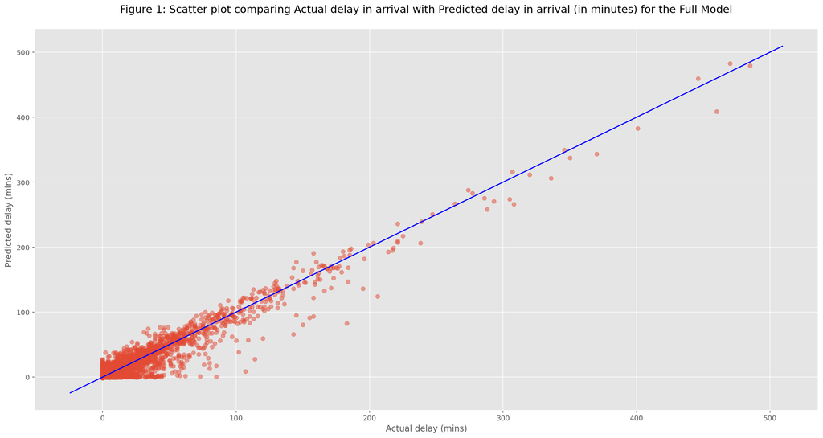

```python
def line(axis, slope, intercept, **kargs):
    xmin, xmax = axis.get_xlim()
    plt.plot([xmin, xmax], [xmin*slope+intercept, xmax*slope+intercept], **kargs)

# Scatter plot
plt.figure(figsize = (20,10))
plt.scatter(residuals_full['actual delay in arrival'], residuals_full['predicted delay in arrival'], alpha=0.5);
line(axis=plt.gca(), slope=1,c="blue", intercept=0);
plt.title('Figure 1: Scatter plot comparing Actual delay in arrival with Predicted delay in arrival (in minutes) for the Full Model\n', fontsize=15);
plt.xlabel('Actual delay (mins)');
plt.ylabel('Predicted delay (mins)');

plt.show();
```

#### Full Model Diagnostic Checks

Now that the regression model is fitted, it is important to inspect the model's regression assumptions. Not inspecting this will likely result in biased and inaccurate Ordinary Least Squares estimations. This may make our conclusions made on the based on OLS model less reliable.

There are some assumptions made with linear regression. Before drawing any inferences, these assumptions must be met. The regression model's key assumptions are:

- The variance of the errors is constant
- The residuals are statistically independent
- The residual distribution of the model is normal
- The relationship between the independent and the target variable is linear

The first diagnostic check is to analyse the leftovers i.e. the residuals which will reveal any patterns that are inexplicable. For analyzing the residuals, we can use a residuals by predicted delay plot. Doing this will. help us work out if fixing the errors in the data set will result improved estimates produced by the model.

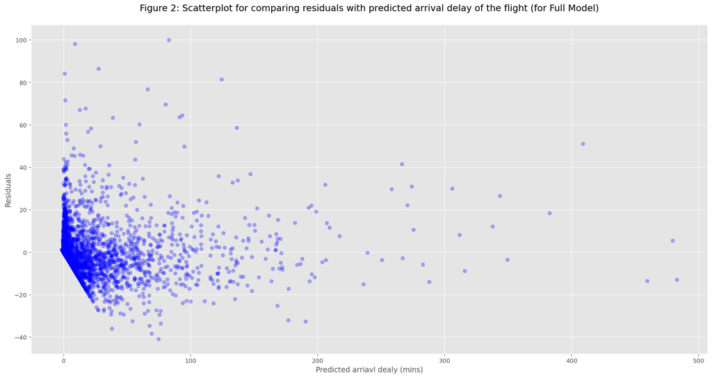

```python
plt.figure(figsize = (20,10))
plt.scatter(residuals_full['predicted delay in arrival'], residuals_full['residual'], alpha=0.3, c ="blue");
plt.xlabel('Predicted arriavl dealy (mins)');
plt.ylabel('Residuals')
plt.title('Figure 2: Scatterplot for comparing residuals with predicted arrival delay of the flight (for Full Model)\n', fontsize=15)
plt.show();
```

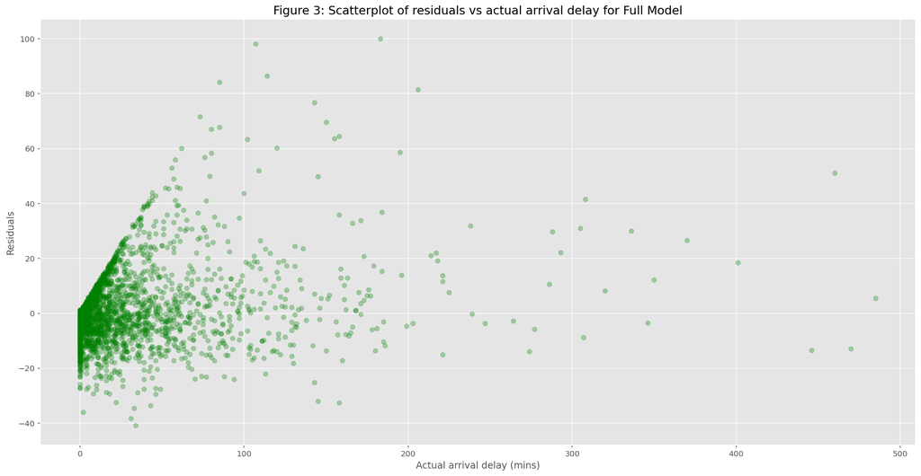

```python
plt.figure(figsize = (20,10))
plt.scatter(residuals_full['actual delay in arrival'], residuals_full['residual'], alpha=0.3, c = "green");
plt.xlabel('Actual arrival delay (mins)');
plt.ylabel('Residuals')
plt.title('Figure 3: Scatterplot of residuals vs actual arrival delay for Full Model', fontsize=15)
plt.show();
```

The residuals plotted are slightly overestimated for the shorter arrival delay predictions and slightly under-estimated when predicting longer arrival delays of the Airline. No normality in the residuals may suggest that there is contamination in data. In order to end up with a reasonable conclusion on the regression model, the residuals need to be normally distribution. We plot a histogram to do this.

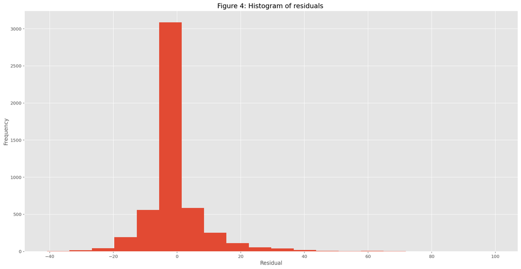

```python
plt.figure(figsize = (20,10))
plt.hist(residuals_full['residual'], bins = 20);
plt.xlabel('Residual');
plt.ylabel('Frequency');
plt.title('Figure 4: Histogram of residuals ', fontsize=15);
plt.show();
```

Next, to get better visualisation of distribution of actual and predicted values we plot a histogram.

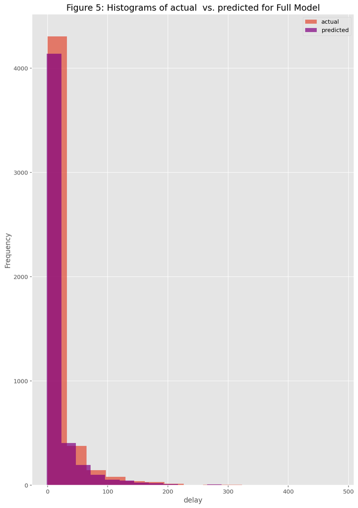

```python
plt.figure(figsize=(10,15))
plt.hist(residuals_full['actual delay in arrival'], label='actual', bins=15, alpha=0.7);
plt.hist(residuals_full['predicted delay in arrival'], label='predicted', bins=20, alpha=0.7, color = "purple");
plt.xlabel('delay');
plt.ylabel('Frequency');
plt.title('Figure 5: Histograms of actual  vs. predicted for Full Model', fontsize=15);
plt.legend()
plt.show();
```

A similar distribution can be seen, with both model's predicted values and the actual values being highly clustered just after 0, making it a right-skewed graph. This is because there is a high proportion of instances where there has been no delay in arrival time of the U.S Airline.

To get a more visible view of the plot, log transformations can be applied to make data more interpretable. The graph is still extremely right skewed.

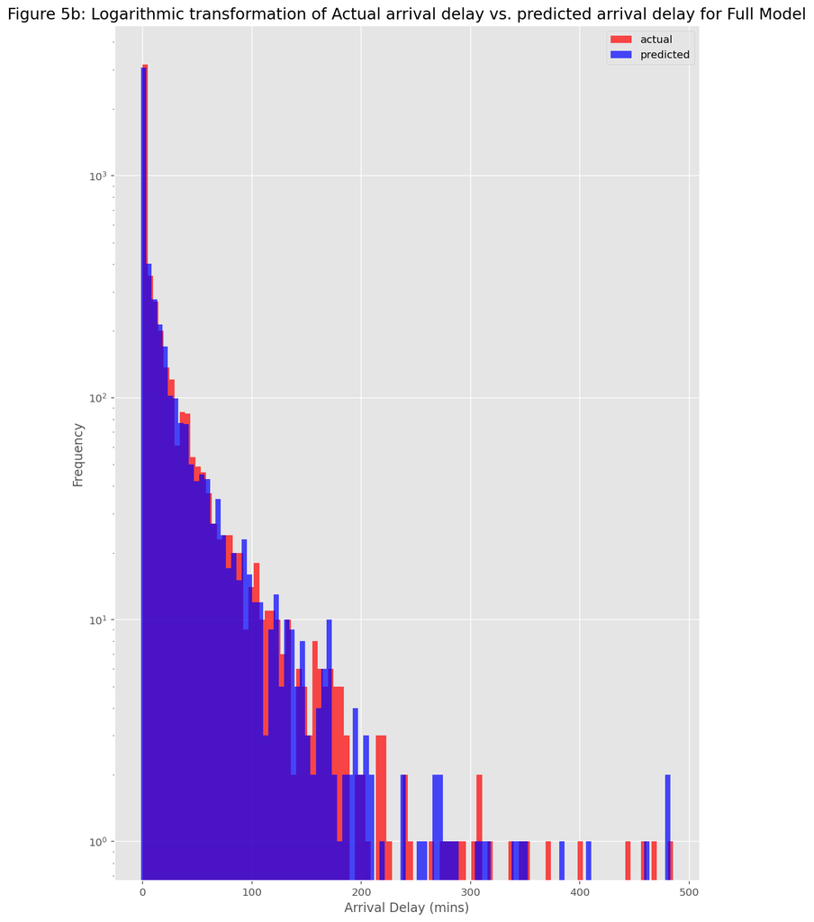

```python
plt.figure(figsize=(10,15))
plt.hist(residuals_full['actual delay in arrival'], label='actual', bins=100, alpha=0.7, color = "red")
plt.hist(residuals_full['predicted delay in arrival'], label='predicted', bins=100, alpha=0.7, color = "blue")
plt.ylabel('Frequency')
plt.xlabel('Arrival Delay (mins)')
plt.title('Figure 5b: Logarithmic transformation of Actual arrival delay vs. predicted arrival delay for Full Model', fontsize=15)
plt.yscale('log')
plt.legend()
plt.show()
```

## Backward feature selection

Now that the diagnostic checks have been completed, we can start the variable elimination process with backward feature selection. This is necessary as the assumptions validated above do not guarantee a valid regression model, for this reason we can obtain a reduced model by eliminating insignificant features. Doing this reduces chances of performance issue like slow processing of data. This will also assist the machine learning model in forming finer predictions. The following code will help in backward feature selection [Credit](https://github.com/vaksakalli/stats_tutorials/blob/master/Regression_Case_Study1_web.ipynb)

```python
# create the patsy model description from formula
patsy_description = patsy.ModelDesc.from_formula(regression_formula)

# initialize feature-selected fit to full model
linreg_fit = model_full_fitted

# do backwards elimination using p-values
p_val_cutoff = 0.05

## WARNING 1: The code below assumes that the Intercept term is present in the model.
## WARNING 2: It will work only with main effects and two-way interactions, if any.

print('\nPerforming backwards feature selection using p-values:')



while True:

    # uncomment the line below if you would like to see the regression summary
    # in each step:
    ### print(linreg_fit.summary())

    pval_series = linreg_fit.pvalues.drop(labels='Intercept')
    pval_series = pval_series.sort_values(ascending=False)
    term = pval_series.index[0]
    pval = pval_series[0]
    if (pval < p_val_cutoff):
        break
    term_components = term.split(':')
    print(f'\nRemoving term "{term}" with p-value {pval:.4}')
    if (len(term_components) == 1): ## this is a main effect term
        patsy_description.rhs_termlist.remove(patsy.Term([patsy.EvalFactor(term_components[0])]))
    else: ## this is an interaction term
        patsy_description.rhs_termlist.remove(patsy.Term([patsy.EvalFactor(term_components[0]),
                                                        patsy.EvalFactor(term_components[1])]))

    linreg_fit = smf.ols(formula=patsy_description, data=encoded_df).fit()

###
## this is the clean fit after backwards elimination
model_reduced_fitted = smf.ols(formula = patsy_description, data = encoded_df).fit()
###

#########
print("\n***")
print(model_reduced_fitted.summary())
print("***")
print(f"Regression number of terms: {len(model_reduced_fitted.model.exog_names)}")
print(f"Regression F-distribution p-value: {model_reduced_fitted.f_pvalue:.4f}")
print(f"Regression R-squared: {model_reduced_fitted.rsquared:.4f}")
print(f"Regression Adjusted R-squared: {model_reduced_fitted.rsquared_adj:.4f}")
```

```
Performing backwards feature selection using p-values:

Removing term "gender_Male" with p-value 0.9827

Removing term "baggage_handle" with p-value 0.8631

Removing term "flight_distance" with p-value 0.8487

Removing term "disloyal_customer" with p-value 0.7585

Removing term "onboard_service" with p-value 0.6247

Removing term "food_drink" with p-value 0.6007

Removing term "seat_comfort" with p-value 0.4165

Removing term "online_boarding" with p-value 0.459

Removing term "legroom_service" with p-value 0.3422

Removing term "entertainment" with p-value 0.3077

Removing term "cleanliness" with p-value 0.5884

Removing term "checkin_service" with p-value 0.3534

Removing term "Personal_travel" with p-value 0.2791

Removing term "online_booking" with p-value 0.2955

Removing term "wifi_service" with p-value 0.4071

Removing term "age" with p-value 0.1043

Removing term "depart_arrive_time" with p-value 0.07822

Removing term "gate_location" with p-value 0.2363

Removing term "Economic" with p-value 0.07399

```

[output cut: 19 more lines]

```
overall_satisfied    -1.0027      0.277     -3.619      0.000      -1.546      -0.459
==============================================================================
Omnibus:                     3023.251   Durbin-Watson:                   2.006
Prob(Omnibus):                  0.000   Jarque-Bera (JB):            60441.891
Skew:                           2.514   Prob(JB):                         0.00
Kurtosis:                      19.274   Cond. No.                         88.1
==============================================================================

Notes:
[1] Standard Errors assume that the covariance matrix of the errors is correctly specified.
***
Regression number of terms: 3
Regression F-distribution p-value: 0.0000
Regression R-squared: 0.9289
Regression Adjusted R-squared: 0.9289
```

A new data frame residual_reduced is created similar to the data frame created for the full model. This will help us explore the reduced model further.

```python
residuals_reduced = pd.DataFrame({'actual delay in arrival': encoded_df['arrival_delay'],
                            'predicted delay in arrival': model_reduced_fitted.fittedvalues,
                            'residual': model_reduced_fitted.resid})
residuals_reduced.head(10)
```

|  | actual delay in arrival | predicted delay in arrival | residual |
| --- | --- | --- | --- |
| 0 | 0 | 1.317438 | -1.317438 |
| 1 | 0 | 1.317438 | -1.317438 |
| 2 | 14 | 0.314773 | 13.685227 |
| 3 | 5 | 1.317438 | 3.682562 |
| 4 | 1 | 0.314773 | 0.685227 |
| 5 | 0 | 1.317438 | -1.317438 |
| 6 | 0 | 1.317438 | -1.317438 |
| 7 | 4 | 12.013870 | -8.013870 |
| 8 | 106 | 84.944091 | 21.055909 |
| 9 | 0 | 0.314773 | -0.314773 |

Since there are a large number of columns eliminated due to a low cut off p- value, a trial can be conducted using a new p- value threshold and backward selection can be re- performed with this adjusted p -value. The new p- values will simply be adjusted based on variables that have a significant effect on the target feature, instead of making use of Holm correction or Hochberg correction method.

Features such as depart_arrive_time has an impact on the arrival delay time. Moreover its p- value is just above the 0.05 threshold. flight_distance can also influence arrival delay of the airline, however, due to its p- value being significantly higher than the threshold p -value . Therefore, depart_arrive_time will be accommodated in the model instead of fully eliminating it. We perform backward feature selection again with a new modified p -value of 0.079.

```python
# create the patsy model description from formula
patsy_description = patsy.ModelDesc.from_formula(regression_formula)

# initialize feature-selected fit to full model
linreg_fit = model_full_fitted

# do backwards elimination using p-values
p_val_cutoff = 0.079

## WARNING 1: The code below assumes that the Intercept term is present in the model.
## WARNING 2: It will work only with main effects and two-way interactions, if any.

print('\nPerforming backwards feature selection using p-values:')



while True:

    # uncomment the line below if you would like to see the regression summary
    # in each step:
    ### print(linreg_fit.summary())

    pval_series = linreg_fit.pvalues.drop(labels='Intercept')
    pval_series = pval_series.sort_values(ascending=False)
    term = pval_series.index[0]
    pval = pval_series[0]
    if (pval < p_val_cutoff):
        break
    term_components = term.split(':')
    print(f'\nRemoving term "{term}" with p-value {pval:.4}')
    if (len(term_components) == 1): ## this is a main effect term
        patsy_description.rhs_termlist.remove(patsy.Term([patsy.EvalFactor(term_components[0])]))
    else: ## this is an interaction term
        patsy_description.rhs_termlist.remove(patsy.Term([patsy.EvalFactor(term_components[0]),
                                                        patsy.EvalFactor(term_components[1])]))

    linreg_fit = smf.ols(formula=patsy_description, data=encoded_df).fit()

###
## this is the clean fit after backwards elimination
model_reduced_fitted = smf.ols(formula = patsy_description, data = encoded_df).fit()
###

#########
print("\n***")
print(model_reduced_fitted.summary())
print("***")
print(f"Regression number of terms: {len(model_reduced_fitted.model.exog_names)}")
print(f"Regression F-distribution p-value: {model_reduced_fitted.f_pvalue:.4f}")
print(f"Regression R-squared: {model_reduced_fitted.rsquared:.4f}")
print(f"Regression Adjusted R-squared: {model_reduced_fitted.rsquared_adj:.4f}")
```

```
Performing backwards feature selection using p-values:

Removing term "gender_Male" with p-value 0.9827

Removing term "baggage_handle" with p-value 0.8631

Removing term "flight_distance" with p-value 0.8487

Removing term "disloyal_customer" with p-value 0.7585

Removing term "onboard_service" with p-value 0.6247

Removing term "food_drink" with p-value 0.6007

Removing term "seat_comfort" with p-value 0.4165

Removing term "online_boarding" with p-value 0.459

Removing term "legroom_service" with p-value 0.3422

Removing term "entertainment" with p-value 0.3077

Removing term "cleanliness" with p-value 0.5884

Removing term "checkin_service" with p-value 0.3534

Removing term "Personal_travel" with p-value 0.2791

Removing term "online_booking" with p-value 0.2955

Removing term "wifi_service" with p-value 0.4071

Removing term "age" with p-value 0.1043

***
                            OLS Regression Results
==============================================================================
Dep. Variable:          arrival_delay   R-squared:                       0.929
Model:                            OLS   Adj. R-squared:                  0.929
Method:                 Least Squares   F-statistic:                 1.090e+04
```

[output cut: 15 more lines]

```
overall_satisfied     -0.6402      0.328     -1.954      0.051      -1.283       0.002
==============================================================================
Omnibus:                     3023.002   Durbin-Watson:                   2.006
Prob(Omnibus):                  0.000   Jarque-Bera (JB):            60455.778
Skew:                           2.514   Prob(JB):                         0.00
Kurtosis:                      19.276   Cond. No.                         186.
==============================================================================

Notes:
[1] Standard Errors assume that the covariance matrix of the errors is correctly specified.
***
Regression number of terms: 7
Regression F-distribution p-value: 0.0000
Regression R-squared: 0.9290
Regression Adjusted R-squared: 0.9290
```

A new data frame 'residual_trial' is created to test the data frame obtained from the adjusted p-value model.

```python
residuals_trial = pd.DataFrame({'actual delay in arrival': encoded_df['arrival_delay'],
                            'predicted delay in arrival': model_reduced_fitted.fittedvalues,
                            'residual': model_reduced_fitted.resid})

residuals_trial.head(10)
```

|  | actual delay in arrival | predicted delay in arrival | residual |
| --- | --- | --- | --- |
| 0 | 0 | 1.515427 | -1.515427 |
| 1 | 0 | 0.753417 | -0.753417 |
| 2 | 14 | 0.190333 | 13.809667 |
| 3 | 5 | 2.438259 | 2.561741 |
| 4 | 1 | 0.190333 | 0.809667 |
| 5 | 0 | 0.830557 | -0.830557 |
| 6 | 0 | 1.515427 | -1.515427 |
| 7 | 4 | 12.002070 | -8.002070 |
| 8 | 106 | 84.547126 | 21.452874 |
| 9 | 0 | 0.478896 | -0.478896 |

Backward selection with the adjusted p- value threshold resulted in addition of new columns that were not intended. This would negatively impact the estimations from the model. Therefore, it is reasonable to stick with the p -value threshold of 0.05. Moreover, there is stil a high 92% of data fit the regression model, which will help achieve an overall good fit for the model.

Using the original data frame (without adjusted p-value) obtained from the first backward selection method, we plot graphs for this reduced model similar to full model.

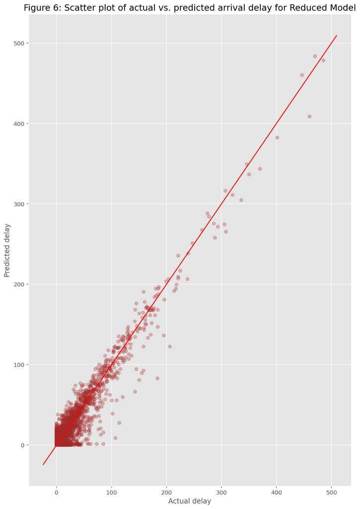

```python
# get a scatter plot
plt.figure(figsize=(10,15))
plt.scatter(residuals_reduced['actual delay in arrival'], residuals_reduced['predicted delay in arrival'], alpha=0.3, c= "brown");
line(axis=plt.gca(), slope=1, intercept=0, c="red");
plt.xlabel('Actual delay');
plt.ylabel('Predicted delay');
plt.title('Figure 6: Scatter plot of actual vs. predicted arrival delay for Reduced Model', fontsize=15);
plt.show();
```

In order to achieve more accurate estimations, further diagnostic checks would need to be performed on the reduced model. The results will then be compared with full model.